# Part I - ( Characteristics of Loanstatus)

## Univariate Exploration

```python
# creating a fuction for ploting count plot(vertical) for univariate plots.
def count_pltx(df, x_axis, order = None):
    '''
        The function plots a count plot with bars placed vertically by accepting
        three variables df, x_axis and order which are the
        dataframe, the variable to plot and order which is set to none.

    '''
    # setting a default color
    base_color = sns.color_palette()[0]
    # setting the fig size for ploting
    plt.figure(figsize = [15, 5])
    # ploting the function with seaborn countplot
    sns.countplot(data=df, x=x_axis, color= base_color, order= order)
    # setting the y label
    plt.ylabel('Count'.title(), fontsize=10,weight=("bold"))
    # setting the x label
    plt.xlabel(x_axis, fontsize=10,weight=("bold"))
    # setting the plot title
    plt.title(f'''The Distribution of {x_axis}'''.title(),fontsize=13,weight=("bold"))
```

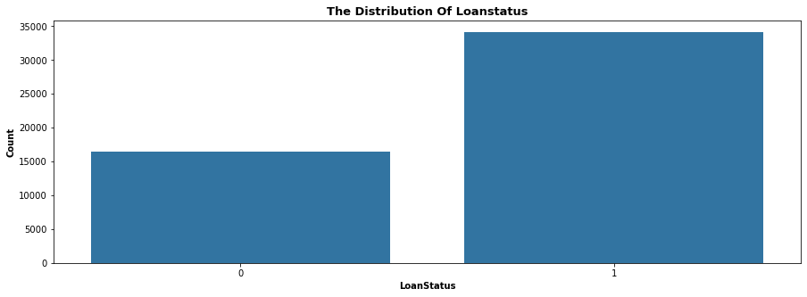

```python
# plotting the LoanStatus with my function count_pltx()
count_pltx(df=loan_data, x_axis='LoanStatus')
```

- The plot shows that less than 20000 borrowers are likely to default (0)
- More than 30000 borrowers will likely not default (1)

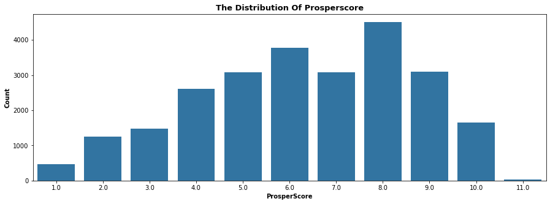

```python
# plotting the 'ProsperScore' with my function count_pltx()
count_pltx(df=loan_data, x_axis='ProsperScore')
```

- The 'ProsperScore' distribution shows a multimodal distribution with the score 8 having the largets count that is above 4000

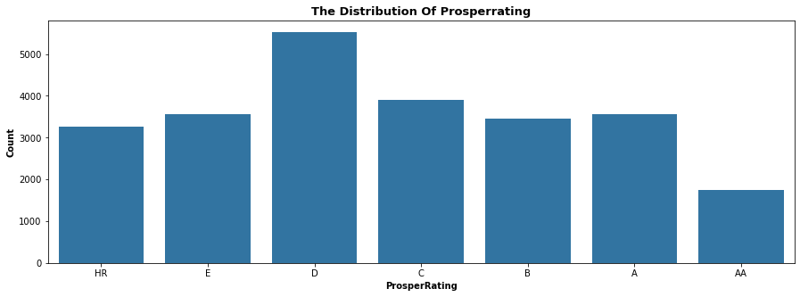

```python
# seting the rating prosper rating order
rating=['HR','E','D','C','B','A','AA']
# ordering it into a categorical type data
rate_set = pd.api.types.CategoricalDtype(ordered=True, categories=rating)
# setting it into the prosper rating
loan_data['ProsperRating'] = loan_data['ProsperRating'].astype(rate_set);
# plotting the 'ProsperRating' with my function count_pltx()
count_pltx(df=loan_data, x_axis='ProsperRating')
```

- The 'ProsperRating' distribution shows that individuals with the highest rating AA are the least in the population and D has the highest population above 5000

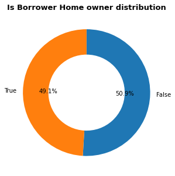

```python
# getting a doughnut plot for the homeowner distribution
counts=loan_data.IsBorrowerHomeowner.value_counts()
 # setting the fig size for ploting
plt.figure(figsize = [15, 5])
plt.pie(counts, labels = counts.index,autopct='%1.1f%%', startangle = 90,
        counterclock = False, wedgeprops = {'width' : 0.4});
plt.title("Is Borrower Home owner distribution", fontsize=13,weight=("bold"));
```

- The 'IsBorrowerHomeowner' plot shows an almost even distribution between borrowers who have a home and do not.

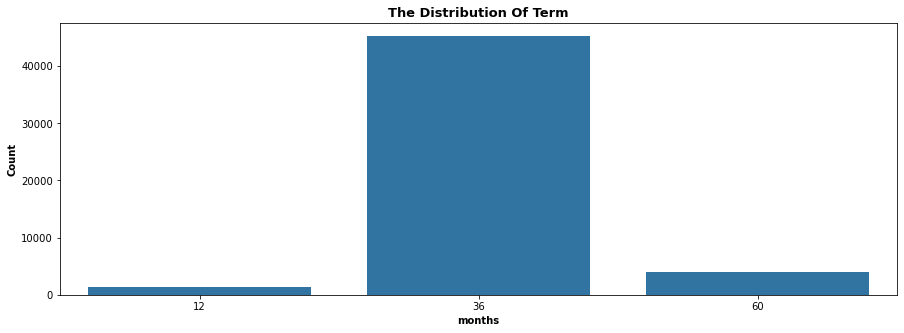

```python
# plotting the 'Term' with my function count_pltx()
count_pltx(df=loan_data, x_axis='Term')
# setting the x label
plt.xlabel('months', fontsize=10,weight=("bold"));
```

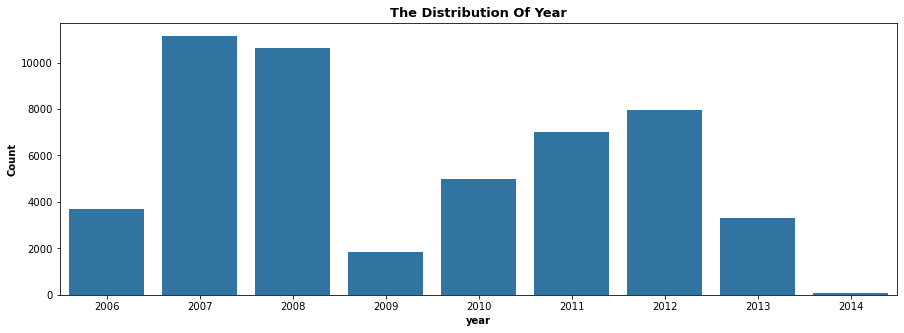

```python
# plotting the 'LoanOriginationDate' with my function count_pltx()
loan_data['year'] = loan_data['LoanOriginationDate'].dt.year
count_pltx(df=loan_data, x_axis='year');
```

```python
# creating a fuction for ploting histogram for univariate plots.
def hist_dist(df, x_axis, bin):
    '''
        The function plots a histogram by accepting
        three variables df, x_axis and bin which are the
        dataframe, the variable to plot and the bin size.

    '''
    # setting the fig size for ploting
    plt.figure(figsize = [15, 5])
    # ploting the function with matplotlib .hist() function
    plt.hist(data=df, x=x_axis, bins=bin)
    # setting the x label
    plt.xlabel(x_axis, fontsize=10,weight=("bold"))
    # setting the y label
    plt.ylabel('Count', fontsize=10,weight=("bold"))
    # setting the plot title
    plt.title(f'''The Distribution of {x_axis}'''.title(),fontsize=13,weight=("bold"))
```

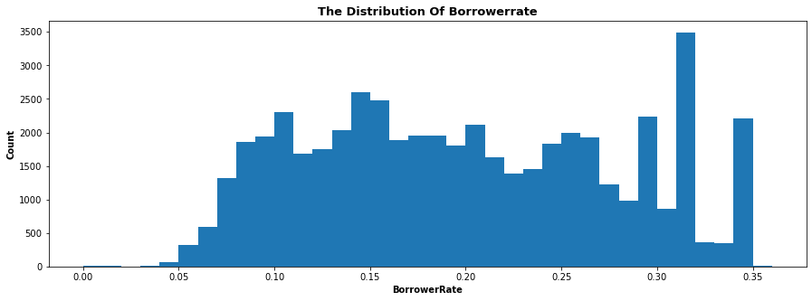

```python
# plotting the borrower rate with my function hist_dist()
hist_dist(df=loan_data, x_axis='BorrowerRate', bin= np.arange(0, loan_data['BorrowerRate'].max() + 0.01, 0.01) )
```

- This plot shows that 'BorrowerRate' feature is a multimodal plot
- It has a first peak around 0.1 and then increased around 0.15 before decreasing then spiked toward 0.3. the largest peak was around 0.31 with a count of 3500

```python
# converting the descriptive statistic of the 'DebtToIncomeRatio' column into a log scale
np.log10(loan_data['DebtToIncomeRatio'].describe())
```

```
count    4.704579
mean    -0.531251
std     -0.133776
min          -inf
25%     -0.886057
50%     -0.698970
75%     -0.508638
max      1.000434
Name: DebtToIncomeRatio, dtype: float64
```

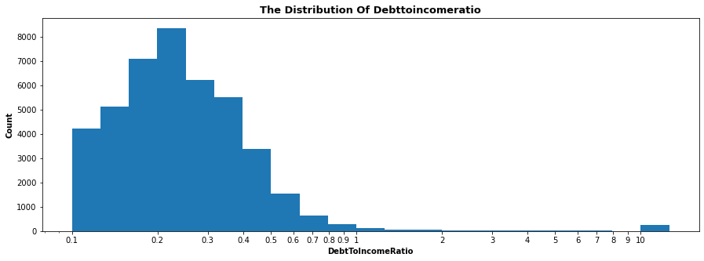

```python
# plotting the DebtToIncomeRatio with my function hist_dist()
hist_dist(df=loan_data, x_axis='DebtToIncomeRatio', bin = 10 ** np.arange(-1, np.log10(loan_data['DebtToIncomeRatio'].max())+0.1, 0.1))
# setting the x-axis into log scale
plt.xscale('log')
# setting new labels
ticks=[ 0.1, 0.2, 0.3, 0.4, 0.5, 0.6, 0.7, 0.8, 0.9, 1, 2, 3, 4, 5, 6, 7, 8, 9, 10 ]
labels=['{}'.format(v) for v in ticks]
plt.xticks(ticks, labels);
```

- The DebtToIncomeRatio feature is right-skeewed
- The DebtToIncomeRatio has most of it data around 0.1 to 1 and the largest peak around 0.2

```python
# converting the descriptive statistic of the 'LoanOriginalAmount' column into a log scale
np.log10(loan_data['LoanOriginalAmount'].describe())
```

```
count    4.704579
mean     3.811147
std      3.726015
min      3.000000
25%      3.477121
50%      3.698970
75%      3.929419
max      4.544068
Name: LoanOriginalAmount, dtype: float64
```

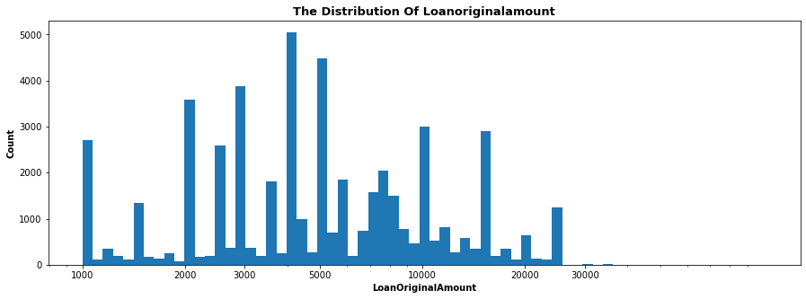

```python
# plotting the 'LoanOriginalAmount' with my function hist_dist()
hist_dist(df=loan_data, x_axis='LoanOriginalAmount', bin=10 ** np.arange(3, 5+0.03, 0.03))
# setting the x-axis into log scale
plt.xscale('log')
# setting new labels
ticks = [1000,2000,3000,5000,10000,20000,30000]
labels = ['{}'.format(v) for v in ticks]
plt.xticks(ticks, labels);
```

```python
def count_ploty(df, y_axis, order= None):
    '''
        The function plots a count plot with bars placed horizontally by accepting
        three variables df, x_axis and order which are the
        dataframe, the variable to plot and order which is set to none.

    '''

      # setting a default color
    base_color = sns.color_palette()[0]
    # setting the fig size for ploting
    plt.figure(figsize = [15, 5])
    # ploting the function with seaborn countplot
    sns.countplot(data=df, y=y_axis, color= base_color, order= order)
    # setting the y label
    plt.xlabel('Count'.title(), fontsize=10,weight=("bold"))
    # setting the x label
    plt.ylabel(y_axis, fontsize=10,weight=("bold"))
    # setting the plot title
    plt.title(f'''The Distribution of {y_axis}'''.title(),fontsize=13,weight=("bold"))
```

```python
# checking the unique values of 'EmploymentStatus' and converting into a list
loan_data['EmploymentStatus'].value_counts().index.to_list()
```

```
['Full-time',
 'Employed',
 'Not available',
 'Self-employed',
 'Part-time',
 'Other',
 'Retired',
 'Not employed']
```

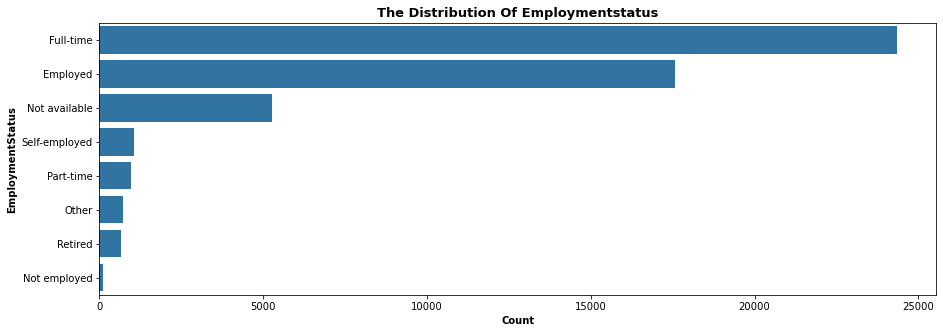

```python
# creating a list of 'EmploymentStatus' in order of descending values
em_order=loan_data['EmploymentStatus'].value_counts().index.to_list()
# plotting the 'EmploymentStatus' with my function count_ploty()
count_ploty(df=loan_data, y_axis='EmploymentStatus', order=em_order)
```

- The 'EmploymentStatus' feature shows that full-time employers were larger in number that is above 20000 with the least Not-employed

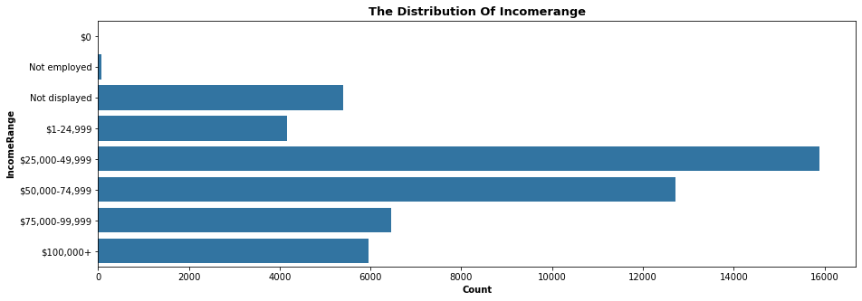

```python
# creating a list of 'IncomeRange' in order
income_orders=['$0', 'Not employed', 'Not displayed', '$1-24,999', '$25,000-49,999', '$50,000-74,999', '$75,000-99,999', '$100,000+']
# plotting the 'IncomeRange' with my function count_ploty()
count_ploty(df=loan_data, y_axis='IncomeRange', order=income_orders)
```

- Large numbers of the borrowers are of the 'IncomeRange' 25,000 - 74,999 range
- There were no borrowers with income $0

```python
# checking the unique values of 'ListingCategory'
loan_data.ListingCategory.value_counts().index
```

```
Index(['Debt Consolidation', 'Not available', 'Other', 'Business',
       'Home Improvement', 'Personal Loan', 'Auto', 'Student Use',
       'Household Expenses', 'Medical/Dental', 'Taxes', 'Vacation',
       'Large Purchases', 'Wedding Loans', 'Motorcycle', 'Engagement Ring',
       'Baby&Adoption', 'Cosmetic Procedure', 'Boat', 'Green Loans', 'RV'],
      dtype='object')
```

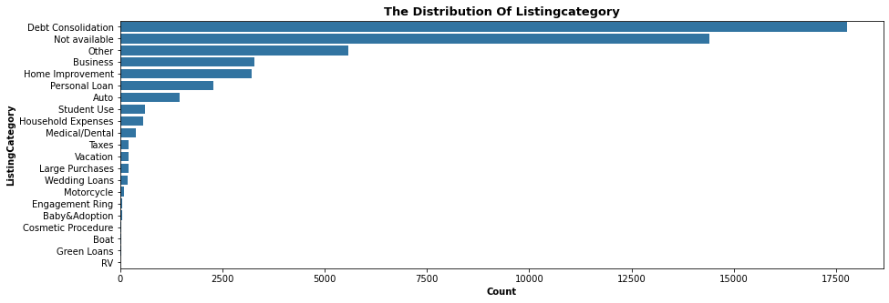

```python
# creating a list of 'ListingCategory' in order of descending values using it's index values
orders= loan_data.ListingCategory.value_counts().index
# plotting the 'ListingCategory' with my function count_ploty()
count_ploty(df=loan_data, y_axis='ListingCategory', order=orders)
```

### Discuss the distribution(s) of your variable(s) of interest. Were there any unusual points? Did you need to perform any transformations?

The loan status feature was grouped into two category during cleaning, the default(0) and Non-default(1). The Non-default(1) borrowers had more counts that is greater than 30000 while the default(0) borrowers had less counts that is less than 20000

### Of the features you investigated, were there any unusual distributions? Did you perform any operations on the data to tidy, adjust, or change the form of the data? If so, why did you do this?

Most of the distributions were normal and some were skewed, I had to use a log function in my scaling to stop the distribution from being skewed to a particular side, also i change the listing category from number to it variable using python replace method thats after changing it to a dictionary for better representation of the data set during the cleaning process.